# Wits_Anova

Elizabeth Telford

12 March 2019

```
##  Hlavac, Marek (2018). stargazer: Well-Formatted Regression and Summary Statistics Tables.
```

```
##  R package version 5.2.2. https://CRAN.R-project.org/package=stargazer
```

% Table created by stargazer v.5.2.2 by Marek Hlavac, Harvard University. E-mail: hlavac at fas.harvard.edu % Date and time: Sun, Apr 14, 2019 - 11:48:41

## 15N

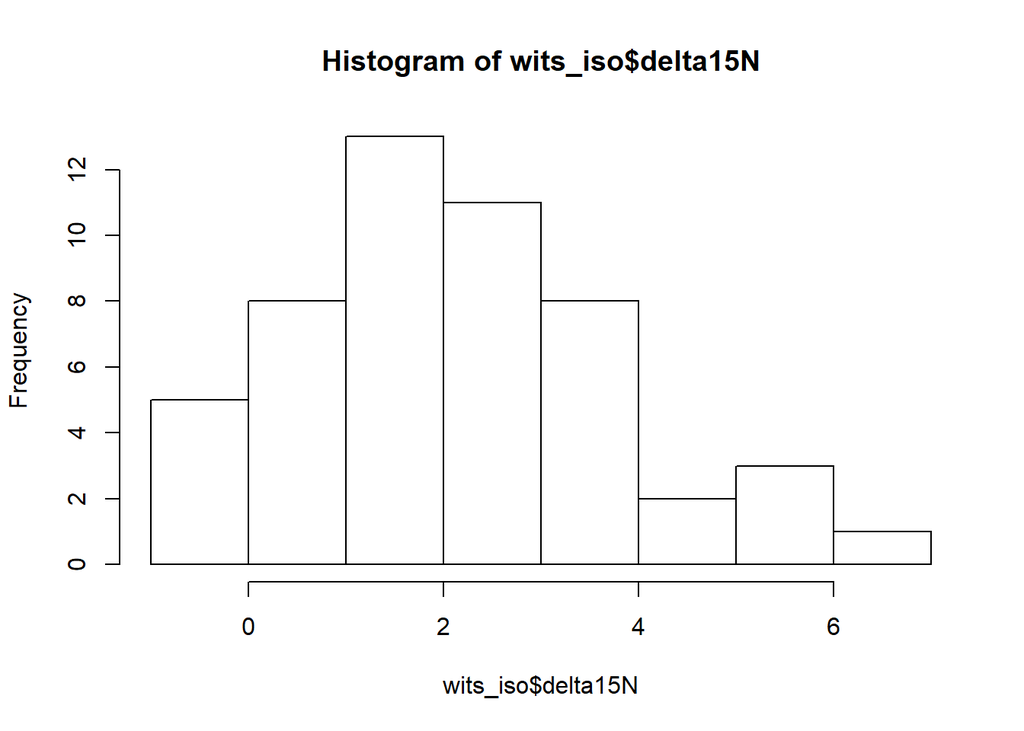

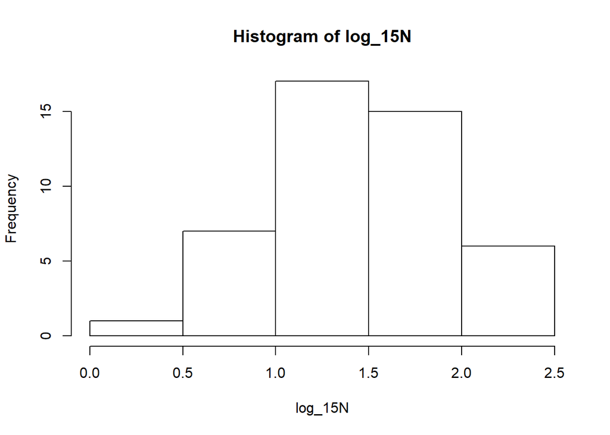

```
##             Df Sum Sq Mean Sq F value Pr(>F)
## Treatment    3  0.385  0.1283   0.516  0.674
## Species      2  0.877  0.4383   1.764  0.185
## Residuals   40  9.941  0.2485
## 5 observations deleted due to missingness
```

```
## Tables of means
## Grand mean
##
## 1.477159
##
##  Treatment
##         2m     3m     4m     C
##      1.496  1.322  1.509  1.57
## rep 10.000 11.000 13.000 12.00
##
##  Species
##         SN    VEX   VS
##      1.644  1.476  1.3
## rep 15.000 17.000 14.0
```

```
##   Tukey multiple comparisons of means
##     95% family-wise confidence level
##
## Fit: aov(formula = log_15N ~ Treatment + Species, data = wits_iso)
##
## $Treatment
##              diff        lwr       upr     p adj
## 3m-2m -0.17427326 -0.7581360 0.4095895 0.8539636
## 4m-2m  0.01283977 -0.5492293 0.5749089 0.9999161
## C-2m   0.07357389 -0.4985870 0.6457348 0.9857152
## 4m-3m  0.18711302 -0.3603251 0.7345512 0.7963680
## C-3m   0.24784715 -0.3099476 0.8056419 0.6359917
## C-4m   0.06073413 -0.4742060 0.5956742 0.9900649
##
## $Species
##              diff        lwr       upr     p adj
## VEX-SN -0.1681749 -0.5980138 0.2616641 0.6108735
## VS-SN  -0.3433028 -0.7942131 0.1076076 0.1657367
## VS-VEX -0.1751279 -0.6130464 0.2627906 0.5977405
```

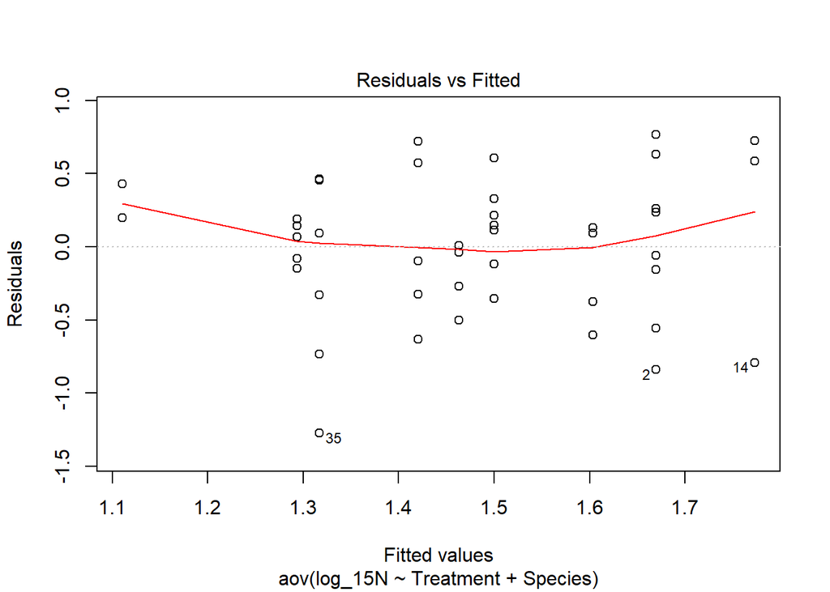

```
## Levene's Test for Homogeneity of Variance (center = median)
##       Df F value Pr(>F)
## group 11  0.8779 0.5694
##       34
```

## 13C

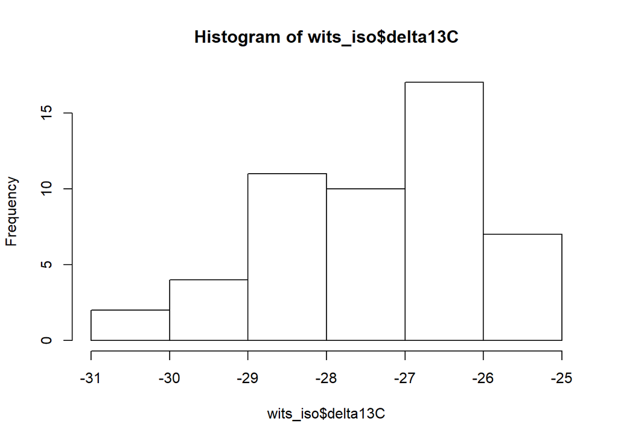

```
##             Df Sum Sq Mean Sq F value   Pr(>F)
## Treatment    3   3.13   1.043    1.19    0.324
## Species      2  49.94  24.970   28.48 1.02e-08 ***
## Residuals   45  39.46   0.877
## ---
## Signif. codes:  0 '***' 0.001 '**' 0.01 '*' 0.05 '.' 0.1 ' ' 1
```

```
## Tables of means
## Grand mean
##
## -27.32439
##
##  Treatment
##        2m     3m     4m     C
##     -27.6 -27.08 -27.12 -27.6
## rep  10.0  15.00  13.00  13.0
##
##  Species
##         SN    VEX     VS
##     -26.33 -28.67 -26.98
## rep  17.00  17.00  17.00
```

```
##   Tukey multiple comparisons of means
##     95% family-wise confidence level
##
## Fit: aov(formula = delta13C ~ Treatment + Species, data = wits_iso)
##
## $Treatment
##               diff        lwr       upr     p adj
## 3m-2m  0.513232534 -0.5065608 1.5330258 0.5412845
## 4m-2m  0.473417621 -0.5772855 1.5241207 0.6287975
## C-2m  -0.003920412 -1.0546235 1.0467827 0.9999996
## 4m-3m -0.039814913 -0.9863778 0.9067480 0.9994867
## C-3m  -0.517152945 -1.4637159 0.4294100 0.4711696
## C-4m  -0.477338032 -1.4571237 0.5024477 0.5679433
##
## $Species
##              diff        lwr        upr     p adj
## VEX-SN -2.3425981 -3.1210016 -1.5641946 0.0000000
## VS-SN  -0.6546438 -1.4330474  0.1237597 0.1147632
## VS-VEX  1.6879543  0.9095508  2.4663578 0.0000115
```

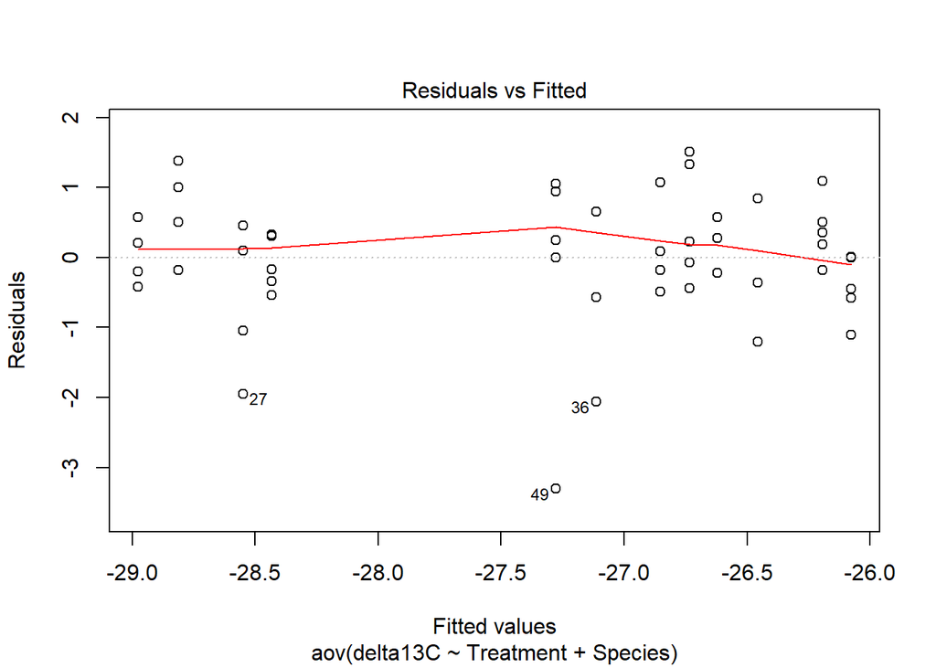

```
## Levene's Test for Homogeneity of Variance (center = median)
##       Df F value Pr(>F)
## group 11  0.9518  0.504
##       39
```

## N

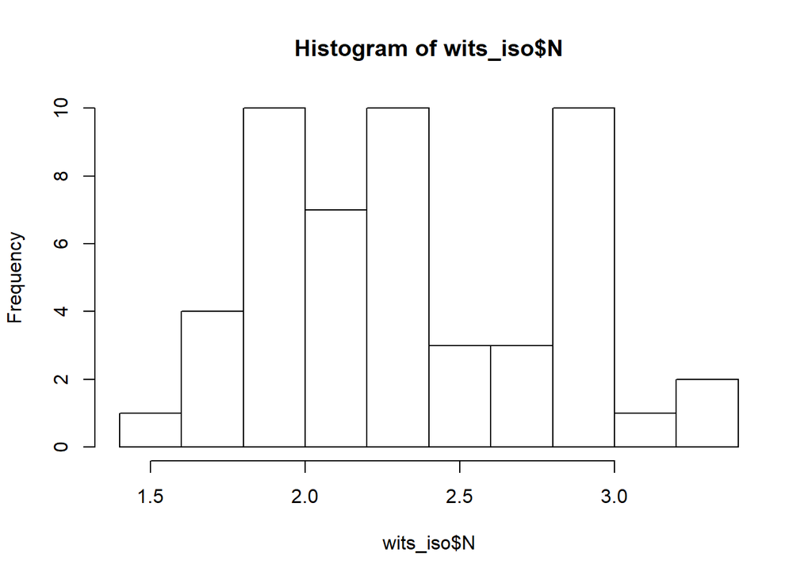

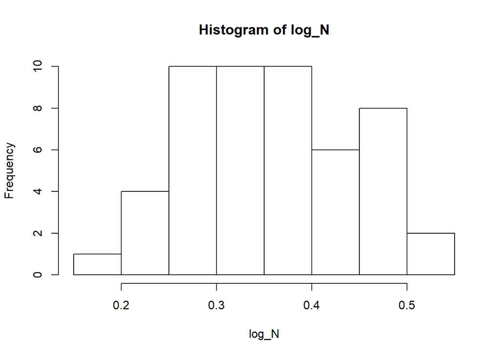

```
##             Df  Sum Sq Mean Sq F value   Pr(>F)
## Treatment    3 0.02749 0.00916   2.521   0.0698 .
## Species      2 0.19504 0.09752  26.822 2.14e-08 ***
## Residuals   45 0.16361 0.00364
## ---
## Signif. codes:  0 '***' 0.001 '**' 0.01 '*' 0.05 '.' 0.1 ' ' 1
```

```
## Tables of means
## Grand mean
##
## 0.3571663
##
##  Treatment
##          2m      3m      4m       C
##      0.3191  0.3864  0.3547  0.3552
## rep 10.0000 15.0000 13.0000 13.0000
##
##  Species
##          SN     VEX      VS
##      0.3098  0.3174  0.4443
## rep 17.0000 17.0000 17.0000
```

```
##   Tukey multiple comparisons of means
##     95% family-wise confidence level
##
## Fit: aov(formula = log_N ~ Treatment + Species, data = wits_iso)
##
## $Treatment
##                diff          lwr        upr     p adj
## 3m-2m  0.0673679930  0.001699323 0.13303666 0.0424128
## 4m-2m  0.0356020979 -0.032056982 0.10326118 0.5036625
## C-2m   0.0361712301 -0.031487850 0.10383031 0.4900212
## 4m-3m -0.0317658951 -0.092718961 0.02918717 0.5118904
## C-3m  -0.0311967628 -0.092149829 0.02975630 0.5271984
## C-4m   0.0005691322 -0.062523285 0.06366155 0.9999949
##
## $Species
##              diff         lwr        upr     p adj
## VEX-SN 0.00763812 -0.04248647 0.05776271 0.9276966
## VS-SN  0.13452575  0.08440115 0.18465034 0.0000002
## VS-VEX 0.12688763  0.07676303 0.17701222 0.0000006
```

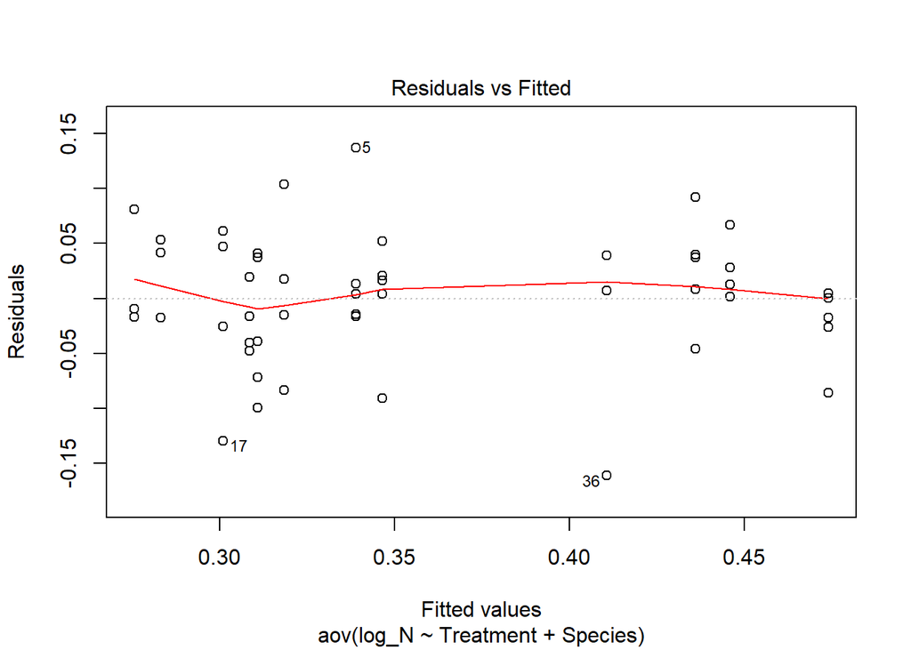

```
## Levene's Test for Homogeneity of Variance (center = median)
##       Df F value Pr(>F)
## group 11  0.4105 0.9427
##       39
```

## c

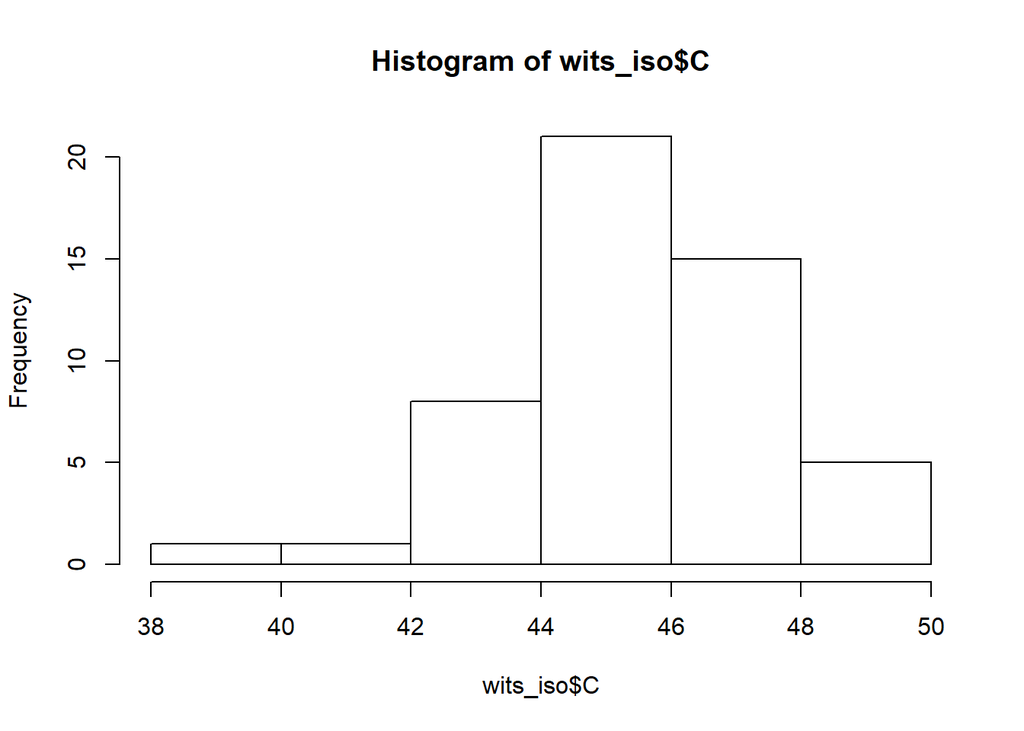

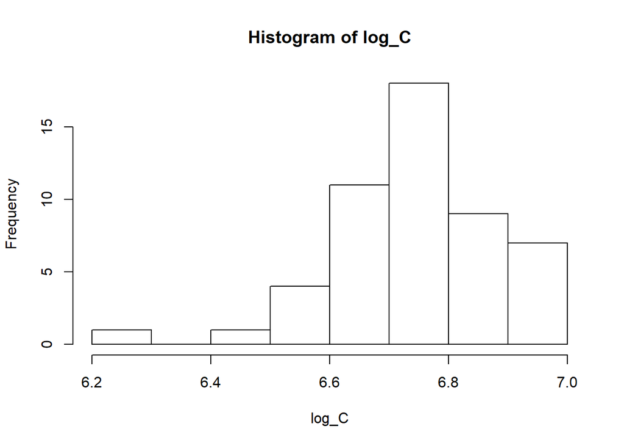

```
##             Df Sum Sq Mean Sq F value Pr(>F)
## Treatment    3  33.07  11.023   3.625 0.0199 *
## Species      2  13.45   6.726   2.212 0.1212
## Residuals   45 136.83   3.041
## ---
## Signif. codes:  0 '***' 0.001 '**' 0.01 '*' 0.05 '.' 0.1 ' ' 1
```

```
## Tables of means
## Grand mean
##
## 45.5086
##
##  Treatment
##        2m    3m    4m     C
##     44.76 46.72 45.28 44.91
## rep 10.00 15.00 13.00 13.00
##
##  Species
##        SN   VEX    VS
##     44.82 45.65 46.05
## rep 17.00 17.00 17.00
```

```
##   Tukey multiple comparisons of means
##     95% family-wise confidence level
##
## Fit: aov(formula = C ~ Treatment + Species, data = wits_iso)
##
## $Treatment
##             diff         lwr         upr     p adj
## 3m-2m  1.9641610  0.06508121  3.86324078 0.0401800
## 4m-2m  0.5193264 -1.43731429  2.47596706 0.8933823
## C-2m   0.1526377 -1.80400302  2.10927833 0.9967656
## 4m-3m -1.4448346 -3.20754330  0.31787408 0.1425378
## C-3m  -1.8115233 -3.57423204 -0.04881465 0.0419206
## C-4m  -0.3666887 -2.19126557  1.45788811 0.9497568
##
## $Species
##             diff        lwr      upr     p adj
## VEX-SN 0.8338825 -0.6156763 2.283441 0.3524381
## VS-SN  1.2293448 -0.2202140 2.678904 0.1108605
## VS-VEX 0.3954624 -1.0540965 1.845021 0.7870020
```

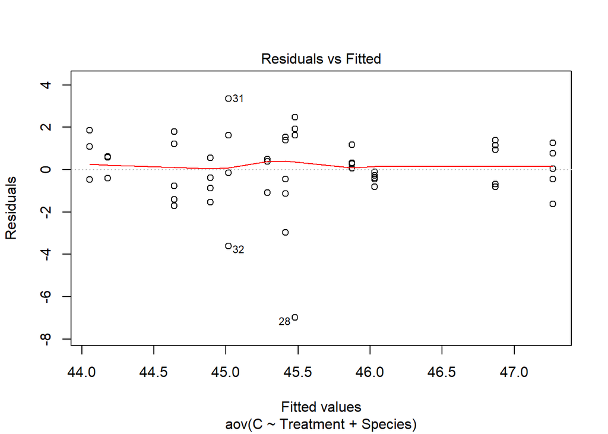

```
## Levene's Test for Homogeneity of Variance (center = median)
##       Df F value Pr(>F)
## group 11   1.046 0.4274
##       39
```

## C:N

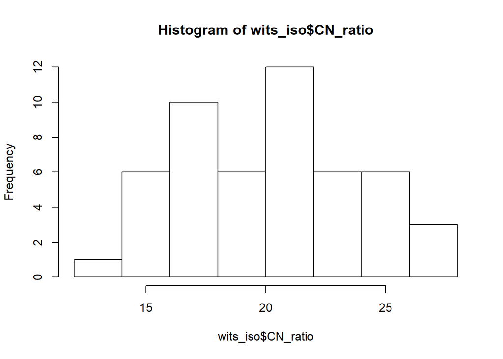

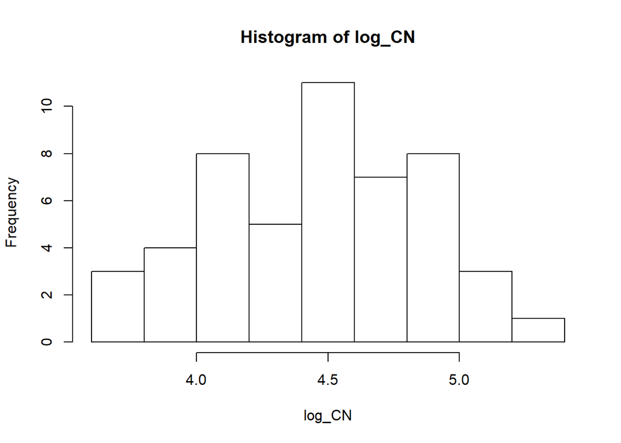

```
##             Df Sum Sq Mean Sq F value   Pr(>F)
## Treatment    3  0.468  0.1562   1.754     0.17
## Species      2  3.957  1.9783  22.217 2.14e-07 ***
## Residuals   44  3.918  0.0890
## ---
## Signif. codes:  0 '***' 0.001 '**' 0.01 '*' 0.05 '.' 0.1 ' ' 1
## 1 observation deleted due to missingness
```

```
## Tables of means
## Grand mean
##
## 4.471034
##
##  Treatment
##         2m     3m     4m      C
##      4.645  4.391  4.495  4.399
## rep 10.000 15.000 13.000 12.000
##
##  Species
##         SN    VEX     VS
##      4.647  4.695  4.082
## rep 16.000 17.000 17.000
```

```
##   Tukey multiple comparisons of means
##     95% family-wise confidence level
##
## Fit: aov(formula = log_CN ~ Treatment + Species, data = wits_iso)
##
## $Treatment
##               diff        lwr        upr     p adj
## 3m-2m -0.254052424 -0.5793152 0.07121033 0.1737685
## 4m-2m -0.150323148 -0.4854446 0.18479828 0.6315526
## C-2m  -0.246055079 -0.5871935 0.09508337 0.2322557
## 4m-3m  0.103729276 -0.1981767 0.40563522 0.7957150
## C-3m   0.007997345 -0.3005740 0.31656869 0.9998792
## C-4m  -0.095731931 -0.4146783 0.22321444 0.8533840
##
## $Species
##               diff        lwr        upr     p adj
## VEX-SN  0.04747214 -0.2046253  0.2995695 0.8916681
## VS-SN  -0.56545210 -0.8175495 -0.3133547 0.0000066
## VS-VEX -0.61292423 -0.8611726 -0.3646759 0.0000010
```

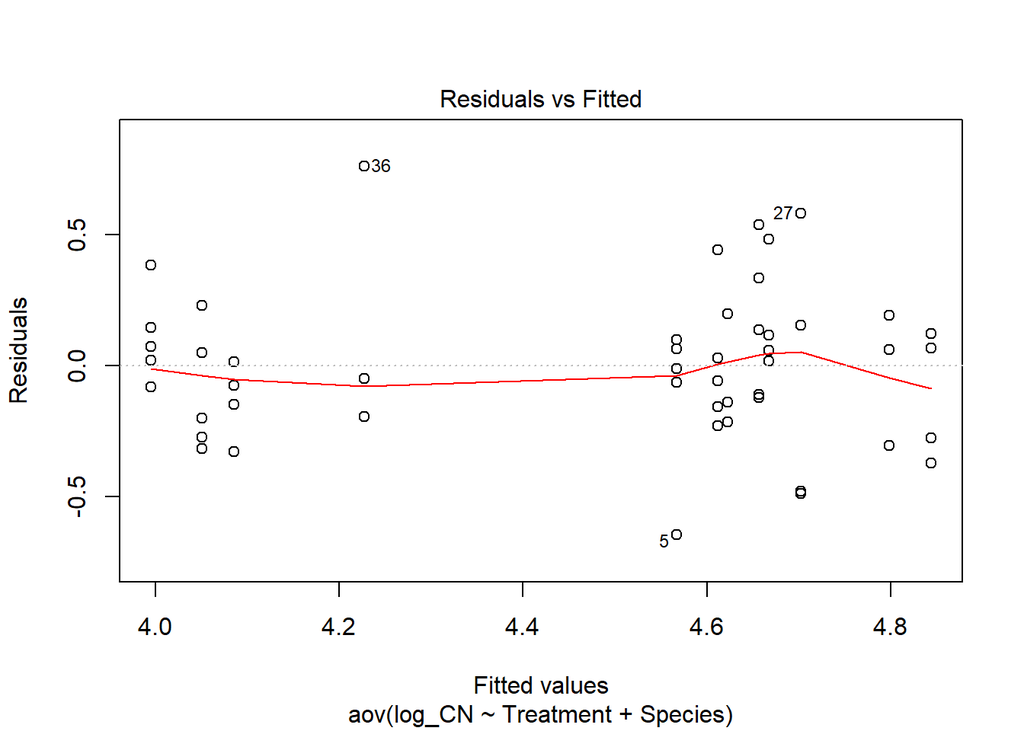

```
## Levene's Test for Homogeneity of Variance (center = median)
##       Df F value Pr(>F)
## group 11  0.8685 0.5771
##       38
```

**Nodule Count**

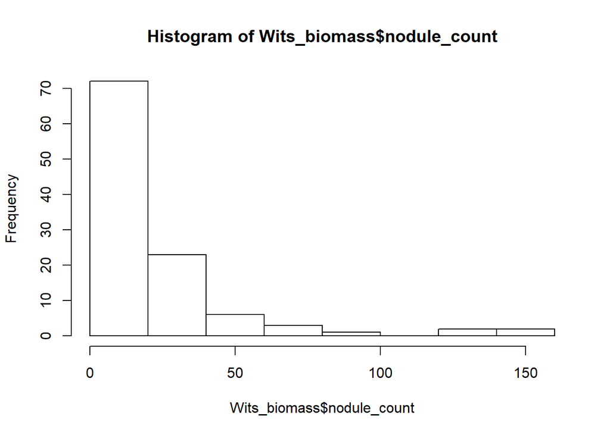

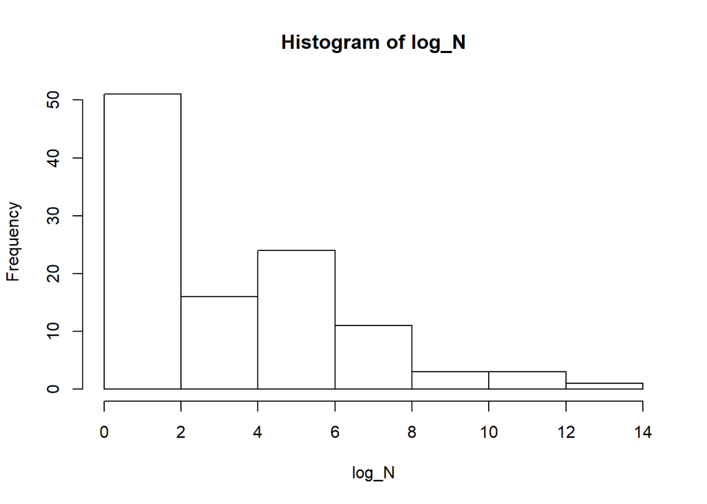

Df Sum Sq Mean Sq F value Pr(>F)  
treatment 3 104.1 34.72 4.342 0.00635 **species 2 112.1 56.04 7.009 0.00140** Residuals 103 823.5 8.00  
— Signif. codes: 0 ‘**’ 0.001 ’**’ 0.01 ’’ 0.05 ‘.’ 0.1 ‘’ 1 Tukey multiple comparisons of means 95% family-wise confidence level

Fit: aov(formula = log_N ~ treatment + species, data = Wits_biomass)

$treatment diff lwr upr p adj 3m-2m 1.6940013 -0.7706924 4.1586949 0.2816888 4m-2m 1.4648626 -0.9430835 3.8728087 0.3895705 C-2m -0.5246469 -2.9426633 1.8933695 0.9417488 4m-3m -0.2291387 -2.0956937 1.6374163 0.9885414 C-3m -2.2186481 -4.0981764 -0.3391199 0.0138093 C-4m -1.9895095 -3.7939806 -0.1850383 0.0246423

$species diff lwr upr p adj VEX-VS -1.8015492 -3.376922 -0.2261761 0.0207900 SN-VS -2.3258321 -3.889774 -0.7618901 0.0017506 SN-VEX -0.5242829 -2.120499 1.0719333 0.7154558

Tables of means Grand mean

3.175631

treatment 2m 3m 4m C 2.427 4.121 3.892 1.902 rep 13.000 29.000 34.000 33.000

species VS VEX SN 4.522 2.721 2.196 rep 38.000 35.000 36.000

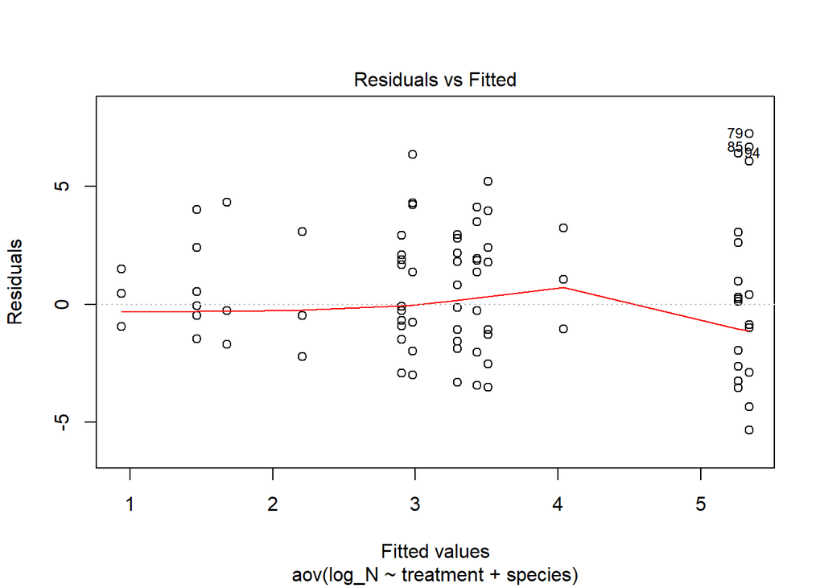

Levene’s Test for Homogeneity of Variance (center = median) Df F value Pr(>F)  
group 11 2.3425 0.01325 97  
— Signif. codes: 0 ‘**’ 0.001 ’**’ 0.01 ’’ 0.05 ‘.’ 0.1 ‘’ 1 **Nodule Weight**

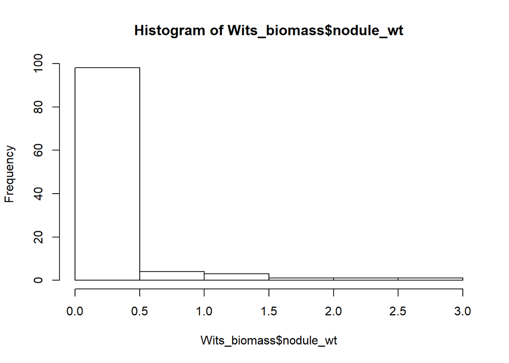

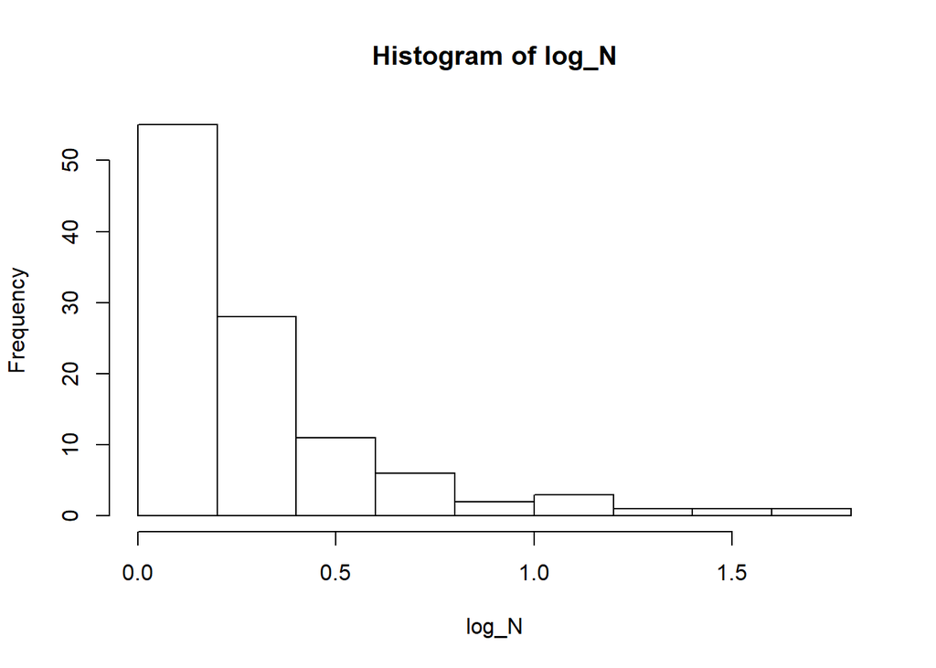

Df Sum Sq Mean Sq F value Pr(>F)  
treatment 3 2.136 0.7120 7.976 7.91e-05 **species 2 1.053 0.5265 5.899 0.00377** Residuals 102 9.105 0.0893  
— Signif. codes: 0 ‘**’ 0.001 ’**’ 0.01 ’’ 0.05 ‘.’ 0.1 ‘’ 1 1 observation deleted due to missingness Tukey multiple comparisons of means 95% family-wise confidence level

Fit: aov(formula = log_N ~ treatment + species + (1 | plot_rep), data = Wits_biomass)

$treatment diff lwr upr p adj 3m-2m 0.32134593 0.06087923 0.58181264 0.0091172 4m-2m 0.14106751 -0.11446639 0.39660141 0.4764275 C-2m -0.03160323 -0.28713713 0.22393067 0.9882839 4m-3m -0.18027842 -0.37890535 0.01834850 0.0893444 C-3m -0.35294916 -0.55157609 -0.15432223 0.0000605 C-4m -0.17267074 -0.36478353 0.01944205 0.0941619

$species diff lwr upr p adj VEX-VS -0.2376721 -0.40542281 -0.06992142 0.0030286 SN-VS -0.1460873 -0.31136041 0.01918578 0.0943898 SN-VEX 0.0915848 -0.07835209 0.26152169 0.4086624

Tables of means Grand mean

0.2757115

treatment 2m 3m 4m C 0.156 0.4773 0.297 0.1244 rep 13.000 29.0000 33.000 33.0000

species VS VEX SN 0.3992 0.1616 0.2531 rep 38.0000 34.0000 36.0000

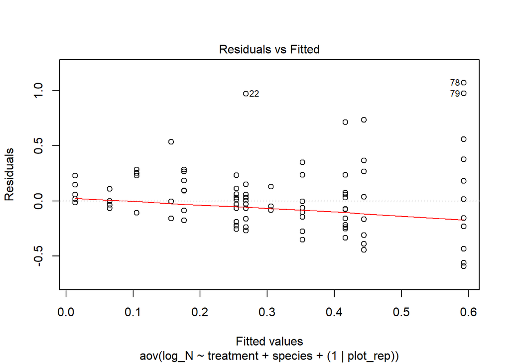

Levene’s Test for Homogeneity of Variance (center = median) Df F value Pr(>F)  
group 11 3.1169 0.001255 ** 96  
— Signif. codes: 0 ‘**’ 0.001 ’**’ 0.01 ’’ 0.05 ‘.’ 0.1 ‘’ 1 **AG wt**

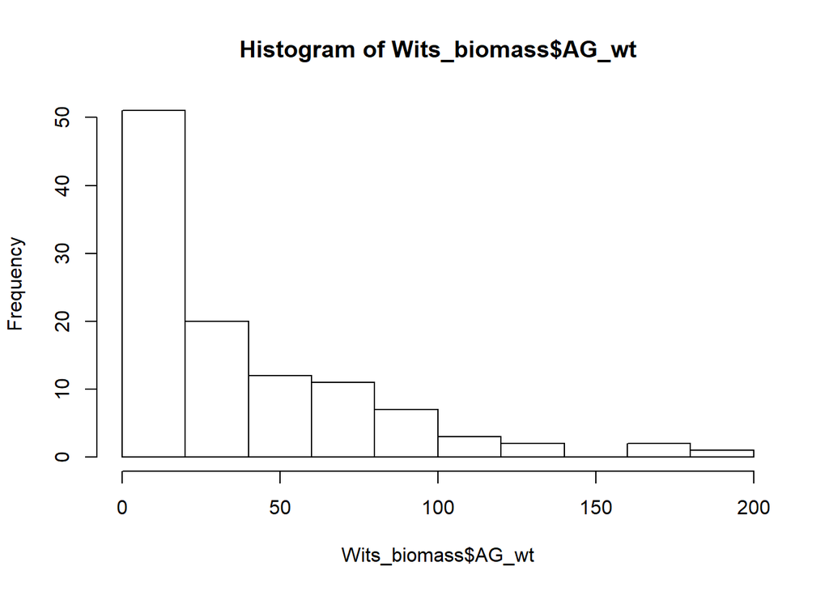

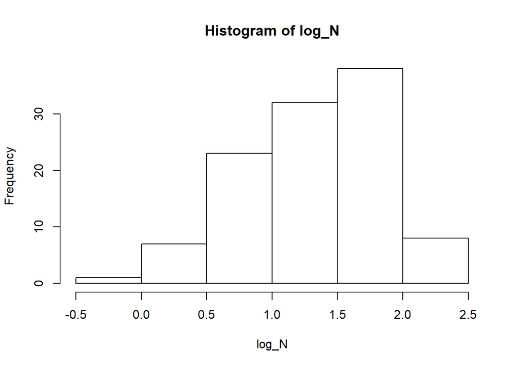

Df Sum Sq Mean Sq F value Pr(>F)  
treatment 3 1.403 0.4677 1.95 0.1262  
species 2 2.187 1.0937 4.56 0.0127 * Residuals 103 24.705 0.2399  
— Signif. codes: 0 ‘**’ 0.001 ’**’ 0.01 ’’ 0.05 ‘.’ 0.1 ‘’ 1 Tukey multiple comparisons of means 95% family-wise confidence level

Fit: aov(formula = log_N ~ treatment + species + (1 | plot_rep), data = Wits_biomass)

$treatment diff lwr upr p adj 3m-2m 0.18823153 -0.23865782 0.6151209 0.6585967 4m-2m 0.08052309 -0.33653749 0.4975837 0.9579124 C-2m 0.32036521 -0.09843956 0.7391700 0.1955834 4m-3m -0.10770844 -0.43099911 0.2155822 0.8202945 C-3m 0.13213368 -0.19340397 0.4576713 0.7145152 C-4m 0.23984212 -0.07269552 0.5523798 0.1932039

$species diff lwr upr p adj VEX-VS -0.1362813 -0.40913877 0.1365761 0.4631433 SN-VS 0.2111704 -0.05970718 0.4820479 0.1574962 SN-VEX 0.3474517 0.07098418 0.6239192 0.0097299

Tables of means Grand mean

1.333512

treatment 2m 3m 4m C 1.161 1.35 1.242 1.482 rep 13.000 29.00 34.000 33.000

species VS VEX SN 1.308 1.171 1.519 rep 38.000 35.000 36.000

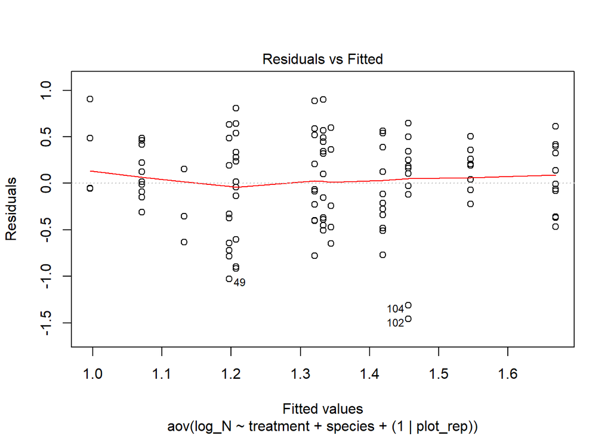

Levene’s Test for Homogeneity of Variance (center = median) Df F value Pr(>F) group 11 0.917 0.5274 97  
**BG wt**

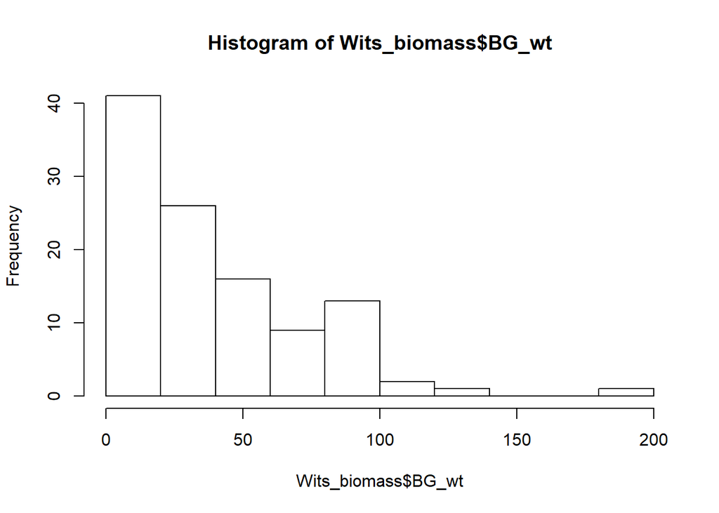

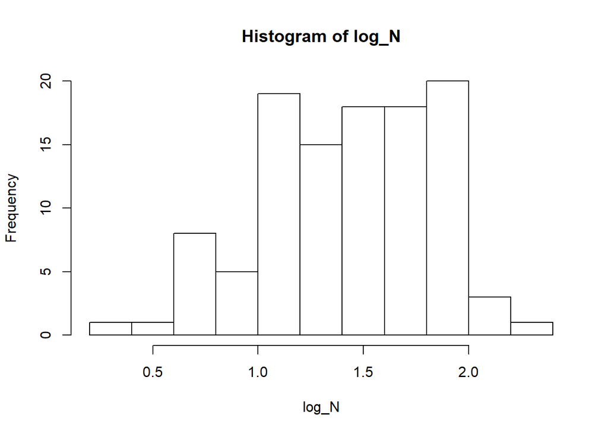

Df Sum Sq Mean Sq F value Pr(>F)  
treatment 3 1.349 0.4498 3.095 0.03022 * species 2 1.560 0.7800 5.366 0.00607 ** Residuals 103 14.971 0.1454  
— Signif. codes: 0 ‘**’ 0.001 ’**’ 0.01 ’’ 0.05 ‘.’ 0.1 ‘’ 1 Tukey multiple comparisons of means 95% family-wise confidence level

Fit: aov(formula = log_N ~ treatment + species + (1 | plot_rep), data = Wits_biomass)

$treatment diff lwr upr p adj 3m-2m 0.15482659 -0.17748683 0.48714001 0.6177224 4m-2m -0.01995699 -0.34461917 0.30470520 0.9985182 C-2m 0.24028736 -0.08573260 0.56630731 0.2241482 4m-3m -0.17478358 -0.42645027 0.07688311 0.2728381 C-3m 0.08546077 -0.16795509 0.33887662 0.8148661 C-4m 0.26024435 0.01694839 0.50354030 0.0311347

$species diff lwr upr p adj VEX-VS -0.23479243 -0.44719920 -0.02238565 0.0265067 SN-VS 0.03865766 -0.17220786 0.24952318 0.9006480 SN-VEX 0.27345008 0.05823304 0.48866713 0.0088336

Tables of means Grand mean

1.429449

treatment 2m 3m 4m C 1.322 1.477 1.302 1.562 rep 13.000 29.000 34.000 33.000

species VS VEX SN 1.492 1.257 1.531 rep 38.000 35.000 36.000

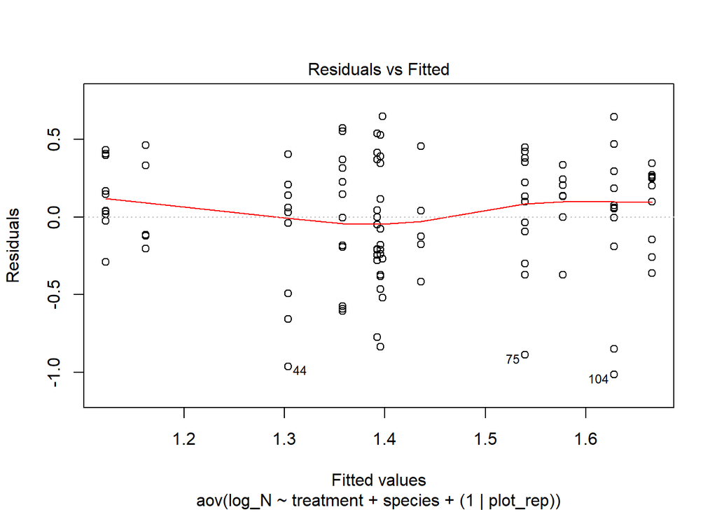

Levene’s Test for Homogeneity of Variance (center = median) Df F value Pr(>F) group 11 1.2641 0.2568 97  
*Total DW*

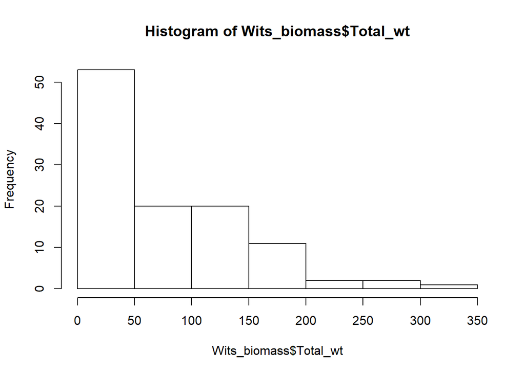

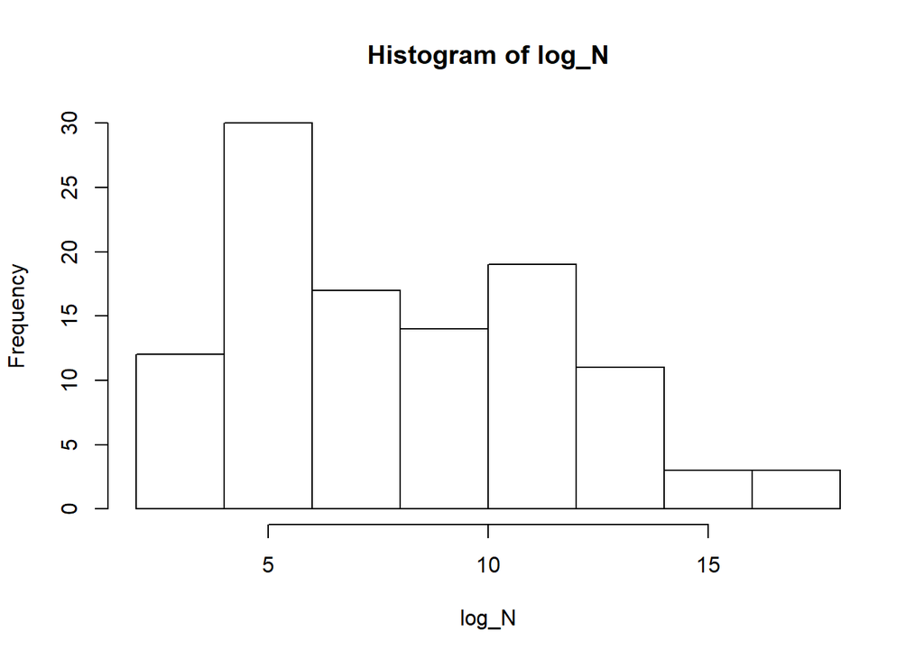

Df Sum Sq Mean Sq F value Pr(>F)  
treatment 3 132.9 44.29 3.90 0.01102 * species 2 135.8 67.91 5.98 0.00349 ** Residuals 103 1169.7 11.36  
— Signif. codes: 0 ‘**’ 0.001 ’**’ 0.01 ’’ 0.05 ‘.’ 0.1 ‘’ 1 Tukey multiple comparisons of means 95% family-wise confidence level

Fit: aov(formula = log_N ~ treatment + species + (1 | plot_rep), data = Wits_biomass)

$treatment diff lwr upr p adj 3m-2m 1.540049454 -1.3972713 4.4773702 0.5214506 4m-2m 0.001770324 -2.8679211 2.8714618 1.0000000 C-2m 2.570626972 -0.3110658 5.4523198 0.0980017 4m-3m -1.538279131 -3.7627628 0.6862046 0.2764845 C-3m 1.030577518 -1.2093671 3.2705222 0.6272897 C-4m 2.568856648 0.4183619 4.7193514 0.0123878

$species diff lwr upr p adj VEX-VS -2.0100213 -3.8874863 -0.1325562 0.0328769 SN-VS 0.6388186 -1.2250233 2.5026604 0.6945738 SN-VEX 2.6488398 0.7465348 4.5511448 0.0036382

Tables of means Grand mean

7.994826

treatment 2m 3m 4m C 6.806 8.346 6.808 9.377 rep 13.000 29.000 34.000 33.000

species VS VEX SN 8.429 6.419 9.068 rep 38.000 35.000 36.000

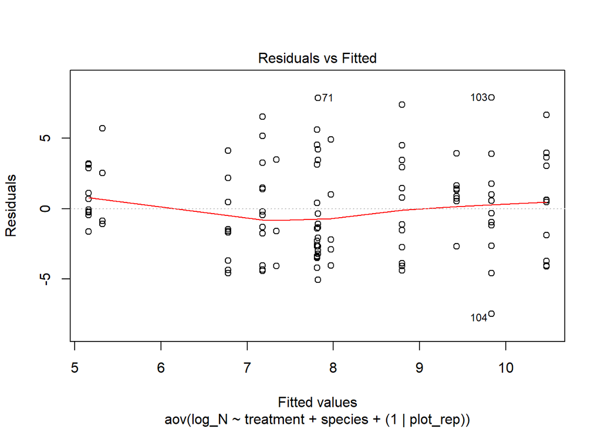

Levene’s Test for Homogeneity of Variance (center = median) Df F value Pr(>F) group 11 0.7151 0.7215 97  
*R:S ratio*

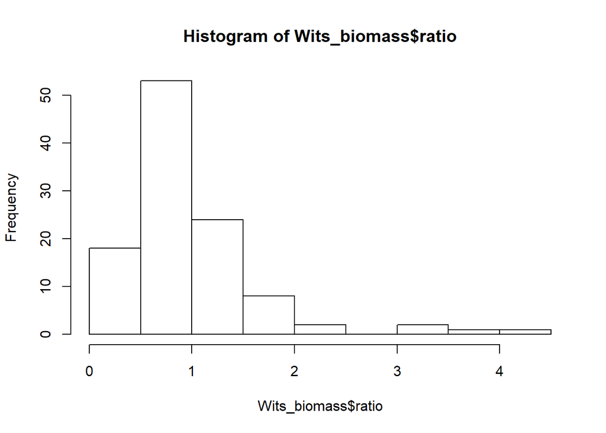

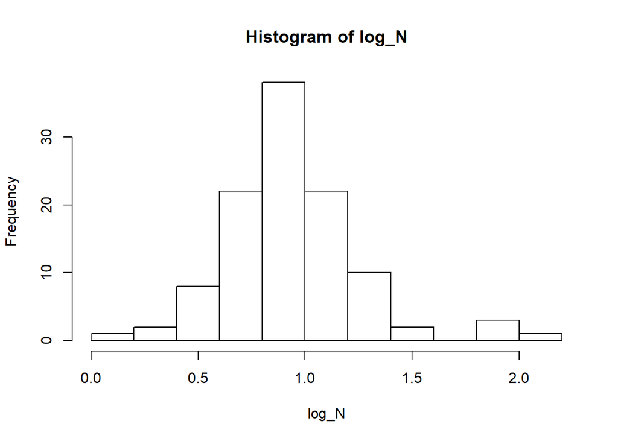

Df Sum Sq Mean Sq F value Pr(>F) treatment 3 0.084 0.02783 0.293 0.830 species 2 0.329 0.16441 1.730 0.182 Residuals 103 9.786 0.09501  
Tukey multiple comparisons of means 95% family-wise confidence level

Fit: aov(formula = log_N ~ treatment + species + (1 | plot_rep), data = Wits_biomass)

$treatment diff lwr upr p adj 3m-2m 0.02498382 -0.2436903 0.2936580 0.9949354 4m-2m 0.06250375 -0.1999844 0.3249919 0.9248679 C-2m 0.07888660 -0.1846993 0.3424725 0.8626554 4m-3m 0.03751993 -0.1659516 0.2409915 0.9630236 C-3m 0.05390279 -0.1509830 0.2587885 0.9018275 C-4m 0.01638286 -0.1803210 0.2130867 0.9963447

$species diff lwr upr p adj VEX-VS 0.03887759 -0.13285248 0.2106077 0.8526130 SN-VS 0.12987177 -0.04061220 0.3003557 0.1708716 SN-VEX 0.09099418 -0.08300798 0.2649963 0.4304234

Tables of means Grand mean

0.9480568

treatment 2m 3m 4m C 0.898 0.923 0.9605 0.9769 rep 13.000 29.000 34.0000 33.0000

species VS VEX SN 0.8927 0.9316 1.023 rep 38.0000 35.0000 36.000

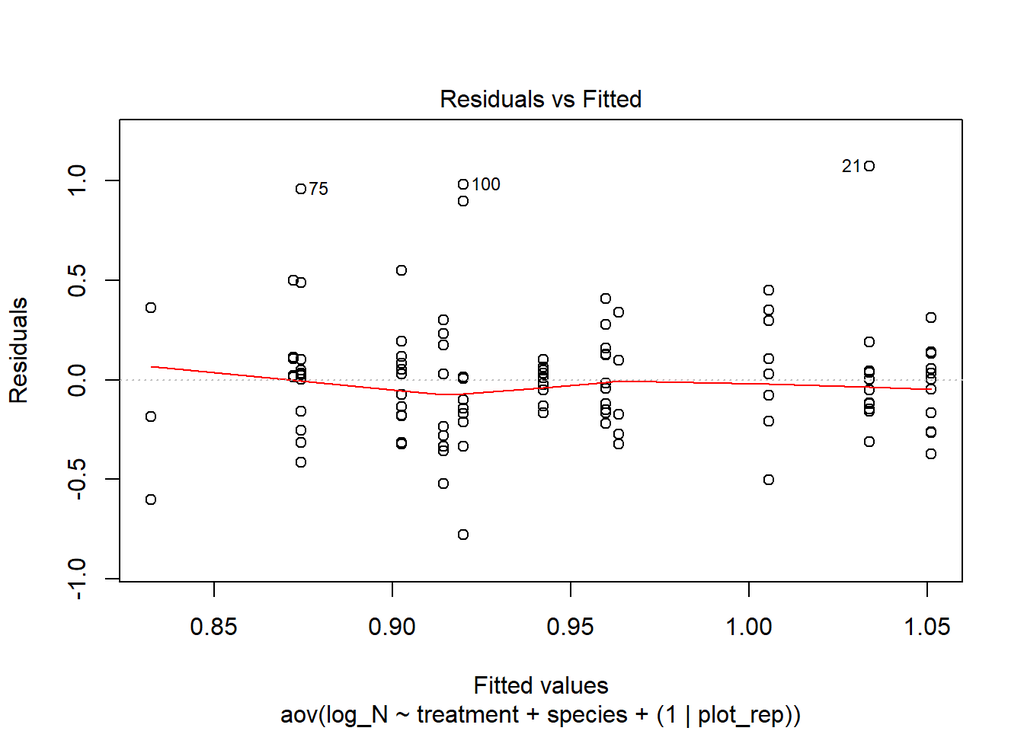

Levene’s Test for Homogeneity of Variance (center = median) Df F value Pr(>F) group 11 0.8328 0.6079 97

**Nodule Count**

|  | Df | Sum Sq | Mean Sq | F value | Pr(>F) |
| --- | --- | --- | --- | --- | --- |
| treatment | 3 | 104.15 | 34.72 | 4.34 | 0.0064 |
| species | 2 | 112.09 | 56.04 | 7.01 | 0.0014 |
| Residuals | 103 | 823.54 | 8.00 |  |  |

**Nodule Weight (grams)**

|  | Df | Sum Sq | Mean Sq | F value | Pr(>F) |
| --- | --- | --- | --- | --- | --- |
| treatment | 3 | 2.14 | 0.71 | 7.98 | 0.0001 |
| species | 2 | 1.05 | 0.53 | 5.90 | 0.0038 |
| Residuals | 102 | 9.11 | 0.09 |  |  |

**Whole Biomass (grams)**

|  | Df | Sum Sq | Mean Sq | F value | Pr(>F) |
| --- | --- | --- | --- | --- | --- |
| treatment | 3 | 132.87 | 44.29 | 3.90 | 0.0110 |
| species | 2 | 135.82 | 67.91 | 5.98 | 0.0035 |
| Residuals | 103 | 1169.66 | 11.36 |  |  |

[output not shown]

**Leaf 15N**

|  | Df | Sum Sq | Mean Sq | F value | Pr(>F) |
| --- | --- | --- | --- | --- | --- |
| Treatment | 3 | 0.38 | 0.13 | 0.52 | 0.6735 |
| Species | 2 | 0.88 | 0.44 | 1.76 | 0.1845 |
| Residuals | 40 | 9.94 | 0.25 |  |  |

[output not shown]

**Leaf C**

|  | Df | Sum Sq | Mean Sq | F value | Pr(>F) |
| --- | --- | --- | --- | --- | --- |
| Treatment | 3 | 33.07 | 11.02 | 3.63 | 0.0199 |
| Species | 2 | 13.45 | 6.73 | 2.21 | 0.1212 |
| Residuals | 45 | 136.83 | 3.04 |  |  |

**Leaf C:N**

|  | Df | Sum Sq | Mean Sq | F value | Pr(>F) |
| --- | --- | --- | --- | --- | --- |
| Treatment | 3 | 0.47 | 0.16 | 1.75 | 0.1700 |
| Species | 2 | 3.96 | 1.98 | 22.22 | 0.0000 |
| Residuals | 44 | 3.92 | 0.09 |  |  |